# Project 1

Shyam Gadhwala

# Data Processing

## First steps

Loading necessary package(s) and reading data

```r
library(tidyverse)
library(readr)
sheet1 <- read_csv("https://www4.stat.ncsu.edu/~online/datasets/EDU01a.csv")
```

Using chaining to select conditional columns, and edit the column name of ‘Area_name’

```r
var1 <- sheet1 %>%
  select(Area_name, STCOU, ends_with("D")) %>%
  rename("area_name" = Area_name)

var1
```

```
## # A tibble: 3,198 × 12
##    area_…¹ STCOU EDU01…² EDU01…³ EDU01…⁴ EDU01…⁵ EDU01…⁶ EDU01…⁷ EDU01…⁸ EDU01…⁹
##    <chr>   <chr>   <dbl>   <dbl>   <dbl>   <dbl>   <dbl>   <dbl>   <dbl>   <dbl>
##  1 UNITED… 00000  4.00e7  4.00e7  4.03e7  4.07e7  4.14e7  4.21e7  4.27e7  4.34e7
##  2 ALABAMA 01000  7.34e5  7.28e5  7.30e5  7.28e5  7.26e5  7.26e5  7.28e5  7.31e5
##  3 Autaug… 01001  6.83e3  6.9 e3  6.92e3  6.85e3  7.01e3  7.14e3  7.15e3  7.38e3
##  4 Baldwi… 01003  1.64e4  1.65e4  1.68e4  1.71e4  1.75e4  1.80e4  1.87e4  1.94e4
##  5 Barbou… 01005  5.07e3  5.10e3  5.07e3  5.16e3  5.17e3  5.25e3  5.14e3  5.11e3
##  6 Bibb, … 01007  3.56e3  3.51e3  3.57e3  3.62e3  3.65e3  3.56e3  3.56e3  3.55e3
##  7 Blount… 01009  7.32e3  7.22e3  7.20e3  7.21e3  7.16e3  7.15e3  7.21e3  7.3 e3
##  8 Bulloc… 01011  2.01e3  1.98e3  1.98e3  1.98e3  1.98e3  2.02e3  2.01e3  2.01e3
##  9 Butler… 01013  4.64e3  4.58e3  4.61e3  4.59e3  4.54e3  4.48e3  4.44e3  4.35e3
## 10 Calhou… 01015  2.09e4  2.09e4  2.09e4  2.08e4  2.08e4  2.05e4  2.05e4  2.01e4
## # … with 3,188 more rows, 2 more variables: EDU010195D <dbl>, EDU010196D <dbl>,
## #   and abbreviated variable names ¹area_name, ²EDU010187D, ³EDU010188D,
## #   ⁴EDU010189D, ⁵EDU010190D, ⁶EDU010191D, ⁷EDU010192D, ⁸EDU010193D,
## #   ⁹EDU010194D
```

Since we are interested in pivoting on enrollment values, applying pivot longer from columns 3 to 12, and adding the data with two new columns -> ‘enroll_details’ (having the data from original DF’s columns names), and ‘value’ (having data for corresponding enrollment values from original data frame)

```r
wideVar1 <- var1 %>%
  pivot_longer(cols = 3:12, names_to = "enroll_details", values_to = "value")

wideVar1
```

```
## # A tibble: 31,980 × 4
##    area_name     STCOU enroll_details    value
##    <chr>         <chr> <chr>             <dbl>
##  1 UNITED STATES 00000 EDU010187D     40024299
##  2 UNITED STATES 00000 EDU010188D     39967624
##  3 UNITED STATES 00000 EDU010189D     40317775
##  4 UNITED STATES 00000 EDU010190D     40737600
##  5 UNITED STATES 00000 EDU010191D     41385442
##  6 UNITED STATES 00000 EDU010192D     42088151
##  7 UNITED STATES 00000 EDU010193D     42724710
##  8 UNITED STATES 00000 EDU010194D     43369917
##  9 UNITED STATES 00000 EDU010195D     43993459
## 10 UNITED STATES 00000 EDU010196D     44715737
## # … with 31,970 more rows
```

Using the str_sub function to get substring from a string. Fetching the 3rd last and 2nd last elements from the column name, converting the value to numeric, and putting an if else condition based on that value to add to a new column ‘year’. Further, using the substring function to create a new column ‘measurement’ by extracting first characters from one of the columns.

```r
updatedData <- wideVar1 %>%
  mutate(year = as.numeric(if_else(as.numeric(str_sub(enroll_details, start = -3, end = -2)) > 22,
                                   str_c("19", str_sub(enroll_details, start = -3, end = -2)),
                                   str_c("20",str_sub(enroll_details, start = -3, end = -2)))))

updatedData <- updatedData %>%
  mutate(measurement = str_sub(enroll_details, start = 1, end = 7))

updatedData
```

```
## # A tibble: 31,980 × 6
##    area_name     STCOU enroll_details    value  year measurement
##    <chr>         <chr> <chr>             <dbl> <dbl> <chr>
##  1 UNITED STATES 00000 EDU010187D     40024299  1987 EDU0101
##  2 UNITED STATES 00000 EDU010188D     39967624  1988 EDU0101
##  3 UNITED STATES 00000 EDU010189D     40317775  1989 EDU0101
##  4 UNITED STATES 00000 EDU010190D     40737600  1990 EDU0101
##  5 UNITED STATES 00000 EDU010191D     41385442  1991 EDU0101
##  6 UNITED STATES 00000 EDU010192D     42088151  1992 EDU0101
##  7 UNITED STATES 00000 EDU010193D     42724710  1993 EDU0101
##  8 UNITED STATES 00000 EDU010194D     43369917  1994 EDU0101
##  9 UNITED STATES 00000 EDU010195D     43993459  1995 EDU0101
## 10 UNITED STATES 00000 EDU010196D     44715737  1996 EDU0101
## # … with 31,970 more rows
```

4. Checking if the area name has a “,” in it. If not, then it is a non county data

```r
nonCountyData <- updatedData %>%
  filter(grepl(",", area_name, fixed=TRUE)==FALSE)

nonCountyData
```

```
## # A tibble: 530 × 6
##    area_name     STCOU enroll_details    value  year measurement
##    <chr>         <chr> <chr>             <dbl> <dbl> <chr>
##  1 UNITED STATES 00000 EDU010187D     40024299  1987 EDU0101
##  2 UNITED STATES 00000 EDU010188D     39967624  1988 EDU0101
##  3 UNITED STATES 00000 EDU010189D     40317775  1989 EDU0101
##  4 UNITED STATES 00000 EDU010190D     40737600  1990 EDU0101
##  5 UNITED STATES 00000 EDU010191D     41385442  1991 EDU0101
##  6 UNITED STATES 00000 EDU010192D     42088151  1992 EDU0101
##  7 UNITED STATES 00000 EDU010193D     42724710  1993 EDU0101
##  8 UNITED STATES 00000 EDU010194D     43369917  1994 EDU0101
##  9 UNITED STATES 00000 EDU010195D     43993459  1995 EDU0101
## 10 UNITED STATES 00000 EDU010196D     44715737  1996 EDU0101
## # … with 520 more rows
```

Checking if the area name has a “,” in it. If so, then it is a county data

```r
countyData <- updatedData %>%
  filter(grepl(",", area_name, fixed=TRUE)==TRUE)

countyData
```

```
## # A tibble: 31,450 × 6
##    area_name   STCOU enroll_details value  year measurement
##    <chr>       <chr> <chr>          <dbl> <dbl> <chr>
##  1 Autauga, AL 01001 EDU010187D      6829  1987 EDU0101
##  2 Autauga, AL 01001 EDU010188D      6900  1988 EDU0101
##  3 Autauga, AL 01001 EDU010189D      6920  1989 EDU0101
##  4 Autauga, AL 01001 EDU010190D      6847  1990 EDU0101
##  5 Autauga, AL 01001 EDU010191D      7008  1991 EDU0101
##  6 Autauga, AL 01001 EDU010192D      7137  1992 EDU0101
##  7 Autauga, AL 01001 EDU010193D      7152  1993 EDU0101
##  8 Autauga, AL 01001 EDU010194D      7381  1994 EDU0101
##  9 Autauga, AL 01001 EDU010195D      7568  1995 EDU0101
## 10 Autauga, AL 01001 EDU010196D      7834  1996 EDU0101
## # … with 31,440 more rows
```

Adding “county” and “state” to respective objects class’ list

```r
class(countyData) <- c("county", class(countyData))
class(nonCountyData) <- c("state", class(nonCountyData))
```

Extracting last two characters of the area name string from county data for abbreviated state name

```r
countyData <- countyData %>%
  mutate(state = str_sub(area_name, start = -2, end = -1))

countyData
```

```
## # A tibble: 31,450 × 7
##    area_name   STCOU enroll_details value  year measurement state
##    <chr>       <chr> <chr>          <dbl> <dbl> <chr>       <chr>
##  1 Autauga, AL 01001 EDU010187D      6829  1987 EDU0101     AL
##  2 Autauga, AL 01001 EDU010188D      6900  1988 EDU0101     AL
##  3 Autauga, AL 01001 EDU010189D      6920  1989 EDU0101     AL
##  4 Autauga, AL 01001 EDU010190D      6847  1990 EDU0101     AL
##  5 Autauga, AL 01001 EDU010191D      7008  1991 EDU0101     AL
##  6 Autauga, AL 01001 EDU010192D      7137  1992 EDU0101     AL
##  7 Autauga, AL 01001 EDU010193D      7152  1993 EDU0101     AL
##  8 Autauga, AL 01001 EDU010194D      7381  1994 EDU0101     AL
##  9 Autauga, AL 01001 EDU010195D      7568  1995 EDU0101     AL
## 10 Autauga, AL 01001 EDU010196D      7834  1996 EDU0101     AL
## # … with 31,440 more rows
```

Creating lists of divisions, and for area name in non county data, checking if it belongs in any list, and creating division column with that division name accordingly

```r
div1 <- c("CONNECTICUT", "MAINE", "MASSACHUSETTS", "NEW HAMPSHIRE", "RHODE ISLAND", "VERMONT")
div2 <- c("NEW JERSEY", "NEW YORK", "PENNSYLVANIA")
div3 <- c("ILLINOIS", "INDIANA", "MICHIGAN", "OHIO", "WISCONSIN")
div4 <- c("IOWA","KANSAS", "MINNESOTA", "MISSOURI", "NEBRASKA", "NORTH DAKOTA", "SOUTH DAKOTA")
div5 <- c("DELAWARE", "FLORIDA", "GEORGIA", "MARYLAND", "NORTH CAROLINA", "SOUTH CAROLINA", "VIRGINIA", "DISTRICT OF COLUMBIA", "District of Columbia", "WEST VIRGINIA")
div6 <- c("ALABAMA", "KENTUCKY", "MISSISSIPPI", "TENNESSEE")
div7 <- c("ARKANSAS", "LOUISIANA", "OKLAHOMA", "TEXAS")
div8 <- c("ARIZONA", "COLORADO", "IDAHO", "MONTANA", "NEVADA", "NEW MEXICO", "UTAH", "WYOMING")
div9 <- c("ALASKA", "CALIFORNIA", "HAWAII", "OREGON", "WASHINGTON")

nonCountyData <- nonCountyData %>%
  mutate(division = if_else(area_name %in% div1, "New England",
                            if_else(area_name %in% div2, "Mid-Atlantic",
                            if_else(area_name %in% div3, "East North Central",
                            if_else(area_name %in% div4, "West North Central",
                            if_else(area_name %in% div5, "South Atlantic",
                            if_else(area_name %in% div6, "East South Central",
                            if_else(area_name %in% div7, "West South Central",
                            if_else(area_name %in% div8, "Mountain",
                            if_else(area_name %in% div9, "Pacific", "ERROR"))))))))))

nonCountyData
```

```
## # A tibble: 530 × 7
##    area_name     STCOU enroll_details    value  year measurement division
##    <chr>         <chr> <chr>             <dbl> <dbl> <chr>       <chr>
##  1 UNITED STATES 00000 EDU010187D     40024299  1987 EDU0101     ERROR
##  2 UNITED STATES 00000 EDU010188D     39967624  1988 EDU0101     ERROR
##  3 UNITED STATES 00000 EDU010189D     40317775  1989 EDU0101     ERROR
##  4 UNITED STATES 00000 EDU010190D     40737600  1990 EDU0101     ERROR
##  5 UNITED STATES 00000 EDU010191D     41385442  1991 EDU0101     ERROR
##  6 UNITED STATES 00000 EDU010192D     42088151  1992 EDU0101     ERROR
##  7 UNITED STATES 00000 EDU010193D     42724710  1993 EDU0101     ERROR
##  8 UNITED STATES 00000 EDU010194D     43369917  1994 EDU0101     ERROR
##  9 UNITED STATES 00000 EDU010195D     43993459  1995 EDU0101     ERROR
## 10 UNITED STATES 00000 EDU010196D     44715737  1996 EDU0101     ERROR
## # … with 520 more rows
```

# Requirements

Function to read the csv file and return a tibble

```r
readCSVAndReturnTibble <- function(url){
  sheet_ <- read_csv(url)
  return(sheet_)
}
```

Function for step 1 and 2 which filters the original data frame, renames area name column, and pivots the data. Adding an optional argument in the function which will take a default value as “values” when no argument is passed when calling a function

```r
stepOneAndTwo <- function(sheet, colName = "values"){

    var2 <- sheet %>%
    select(Area_name, STCOU, ends_with("D")) %>%
    rename("area_name" = Area_name) %>%
    pivot_longer(cols = 3:12, names_to = "enroll_details", values_to = colName)

  return(var2)
}
```

Function to do step 3, which takes input from step 1 and 2’s function’s output. This function adds a column for year by extracting the 3rd last and 2nd last characters of the enroll_details column, and checks for correct year assigning criteria. It also adds a column ‘measurement’ by extracting first 7 characters from existing rnroll_details column

```r
stepThree <- function(input_ = stepOneAndTwo(sheet_, colName)){
  retVar <- input_ %>%
    mutate(year = as.numeric(if_else(as.numeric(str_sub(enroll_details, start = -3, end = -2)) > 22,
                                   str_c("19", str_sub(enroll_details, start = -3, end = -2)),
                                   str_c("20",str_sub(enroll_details, start = -3, end = -2)))))

  retVar <- retVar %>%
    mutate(measurement = str_sub(enroll_details, start = 1, end = 7))

  return(retVar)
}
```

Function to extract state name after from area_name. Function also adds “county” to the object’s class list

```r
getCountyData <- function(inputTibble_){
  countyData <- inputTibble_ %>%
  #filter(grepl(",", area_name, fixed=TRUE)==TRUE) %>%
    mutate(state = str_sub(area_name, start = -2, end = -1))

  class(countyData) <- c("county", class(countyData))
  return(countyData)
}
```

Function to add division name after conditional area_name checks. Function also adds “state” to the object’s class list

```r
getNonCountyData <- function(input_){
  div1 <- c("CONNECTICUT", "MAINE", "MASSACHUSETTS", "NEW HAMPSHIRE", "RHODE ISLAND", "VERMONT")
  div2 <- c("NEW JERSEY", "NEW YORK", "PENNSYLVANIA")
  div3 <- c("ILLINOIS", "INDIANA", "MICHIGAN", "OHIO", "WISCONSIN")
  div4 <- c("IOWA","KANSAS", "MINNESOTA", "MISSOURI", "NEBRASKA", "NORTH DAKOTA", "SOUTH DAKOTA")
  div5 <- c("DELAWARE", "FLORIDA", "GEORGIA", "MARYLAND", "NORTH CAROLINA",
            "SOUTH CAROLINA", "VIRGINIA", "DISTRICT OF COLUMBIA", "WEST VIRGINIA")
  div6 <- c("ALABAMA", "KENTUCKY", "MISSISSIPPI", "TENNESSEE")
  div7 <- c("ARKANSAS", "LOUISIANA", "OKLAHOMA", "TEXAS")
  div8 <- c("ARIZONA", "COLORADO", "IDAHO", "MONTANA", "NEVADA", "NEW MEXICO", "UTAH", "WYOMING")
  div9 <- c("ALASKA", "CALIFORNIA", "HAWAII", "OREGON", "WASHINGTON")

  nonCountyData <- input_ %>%
    #filter(grepl(",", area_name, fixed=TRUE)==FALSE) %>%
    mutate(division = if_else(toupper(area_name) %in% div1, "New England",
                            if_else(toupper(area_name) %in% div2, "Mid-Atlantic",
                            if_else(toupper(area_name) %in% div3, "East North Central",
                            if_else(toupper(area_name) %in% div4, "West North Central",
                            if_else(toupper(area_name) %in% div5, "South Atlantic",
                            if_else(toupper(area_name) %in% div6, "East South Central",
                            if_else(toupper(area_name) %in% div7, "West South Central",
                            if_else(toupper(area_name) %in% div8, "Mountain",
                            if_else(toupper(area_name) %in% div9, "Pacific", "ERROR"))))))))))

  class(nonCountyData) <- c("state", class(nonCountyData))

  return(nonCountyData)
}
```

Function to segregate county data, and non county data, and pass it on to above two fucntions to add details about their corresponding state/division. This function returns a list of two tibbles, first element for county tibble, and second element for non county tibble.

```r
stepFour <- function(input_ = stepThree(stepOneAndTwo(sheet_, colName))){
  nonCountyData <- input_ %>%
    filter(grepl(",", area_name, fixed=TRUE)==FALSE)

  countyData <- input_ %>%
    filter(grepl(",", area_name, fixed=TRUE)==TRUE)

  countyTib <- getCountyData(countyData)
  nonCountyTib <- getNonCountyData(nonCountyData)

  return(list(County=countyTib, Non_County=nonCountyTib))

}
```

Wrapper function to combine all the above defined functions to achieve final required tibble from a single function. It has an optional argument to define column name. If no argument is passed, it will take default value as “Default_NAME”

```r
my_wrapper <- function(url, colName = "Default_NAME"){
  a <- readCSVAndReturnTibble(url)
  b <- stepOneAndTwo(a, colName)
  c <- stepThree(b)
  d <- stepFour(c)

  return(d)
}
```

# Call It and Combine Your Data

Calling wrapper functions using appropriate arguments.

## Wrapper Function’s Output for 1st csv file

```r
tibble_1 <- my_wrapper("https://www4.stat.ncsu.edu/~online/datasets/EDU01a.csv", "E_Values")
tibble_1
```

```
## $County
## # A tibble: 31,450 × 7
##    area_name   STCOU enroll_details E_Values  year measurement state
##    <chr>       <chr> <chr>             <dbl> <dbl> <chr>       <chr>
##  1 Autauga, AL 01001 EDU010187D         6829  1987 EDU0101     AL
##  2 Autauga, AL 01001 EDU010188D         6900  1988 EDU0101     AL
##  3 Autauga, AL 01001 EDU010189D         6920  1989 EDU0101     AL
##  4 Autauga, AL 01001 EDU010190D         6847  1990 EDU0101     AL
##  5 Autauga, AL 01001 EDU010191D         7008  1991 EDU0101     AL
##  6 Autauga, AL 01001 EDU010192D         7137  1992 EDU0101     AL
##  7 Autauga, AL 01001 EDU010193D         7152  1993 EDU0101     AL
##  8 Autauga, AL 01001 EDU010194D         7381  1994 EDU0101     AL
##  9 Autauga, AL 01001 EDU010195D         7568  1995 EDU0101     AL
## 10 Autauga, AL 01001 EDU010196D         7834  1996 EDU0101     AL
## # … with 31,440 more rows
##
## $Non_County
## # A tibble: 530 × 7
##    area_name     STCOU enroll_details E_Values  year measurement division
##    <chr>         <chr> <chr>             <dbl> <dbl> <chr>       <chr>
##  1 UNITED STATES 00000 EDU010187D     40024299  1987 EDU0101     ERROR
##  2 UNITED STATES 00000 EDU010188D     39967624  1988 EDU0101     ERROR
##  3 UNITED STATES 00000 EDU010189D     40317775  1989 EDU0101     ERROR
##  4 UNITED STATES 00000 EDU010190D     40737600  1990 EDU0101     ERROR
##  5 UNITED STATES 00000 EDU010191D     41385442  1991 EDU0101     ERROR
##  6 UNITED STATES 00000 EDU010192D     42088151  1992 EDU0101     ERROR
##  7 UNITED STATES 00000 EDU010193D     42724710  1993 EDU0101     ERROR
##  8 UNITED STATES 00000 EDU010194D     43369917  1994 EDU0101     ERROR
##  9 UNITED STATES 00000 EDU010195D     43993459  1995 EDU0101     ERROR
## 10 UNITED STATES 00000 EDU010196D     44715737  1996 EDU0101     ERROR
## # … with 520 more rows
```

## Wrapper Function’s Output for 2nd csv file

```r
tibble_2 <- my_wrapper("https://www4.stat.ncsu.edu/~online/datasets/EDU01b.csv", "E_Values")
tibble_2
```

```
## $County
## # A tibble: 31,450 × 7
##    area_name   STCOU enroll_details E_Values  year measurement state
##    <chr>       <chr> <chr>             <dbl> <dbl> <chr>       <chr>
##  1 Autauga, AL 01001 EDU010197D         8099  1997 EDU0101     AL
##  2 Autauga, AL 01001 EDU010198D         8211  1998 EDU0101     AL
##  3 Autauga, AL 01001 EDU010199D         8489  1999 EDU0101     AL
##  4 Autauga, AL 01001 EDU010200D         8912  2000 EDU0102     AL
##  5 Autauga, AL 01001 EDU010201D         8626  2001 EDU0102     AL
##  6 Autauga, AL 01001 EDU010202D         8762  2002 EDU0102     AL
##  7 Autauga, AL 01001 EDU015203D         9105  2003 EDU0152     AL
##  8 Autauga, AL 01001 EDU015204D         9200  2004 EDU0152     AL
##  9 Autauga, AL 01001 EDU015205D         9559  2005 EDU0152     AL
## 10 Autauga, AL 01001 EDU015206D         9652  2006 EDU0152     AL
## # … with 31,440 more rows
##
## $Non_County
## # A tibble: 530 × 7
##    area_name     STCOU enroll_details E_Values  year measurement division
##    <chr>         <chr> <chr>             <dbl> <dbl> <chr>       <chr>
##  1 UNITED STATES 00000 EDU010197D     44534459  1997 EDU0101     ERROR
##  2 UNITED STATES 00000 EDU010198D     46245814  1998 EDU0101     ERROR
##  3 UNITED STATES 00000 EDU010199D     46368903  1999 EDU0101     ERROR
##  4 UNITED STATES 00000 EDU010200D     46818690  2000 EDU0102     ERROR
##  5 UNITED STATES 00000 EDU010201D     47127066  2001 EDU0102     ERROR
##  6 UNITED STATES 00000 EDU010202D     47606570  2002 EDU0102     ERROR
##  7 UNITED STATES 00000 EDU015203D     48506317  2003 EDU0152     ERROR
##  8 UNITED STATES 00000 EDU015204D     48693287  2004 EDU0152     ERROR
##  9 UNITED STATES 00000 EDU015205D     48978555  2005 EDU0152     ERROR
## 10 UNITED STATES 00000 EDU015206D     49140702  2006 EDU0152     ERROR
## # … with 520 more rows
```

This function combines two input data frames/ tibbles using the bind_rows() function from tidyverse. A list is returned from this function which would have two elements, for for county tibble, and another for non-county tibble.

```r
combine_dfs <- function(tibb1, tibb2){
  temp_tib_1 <- bind_rows(tibb1$County, tibb2$County)
  temp_tib_2 <- bind_rows(tibb1$Non_County, tibb2$Non_County)

  comb_df <- list(County = temp_tib_1, Non_County = temp_tib_2)

  return(comb_df)
}
```

## Call Combine Function

```r
combine_dfs(tibble_1, tibble_2)
```

```
## $County
## # A tibble: 62,900 × 7
##    area_name   STCOU enroll_details E_Values  year measurement state
##    <chr>       <chr> <chr>             <dbl> <dbl> <chr>       <chr>
##  1 Autauga, AL 01001 EDU010187D         6829  1987 EDU0101     AL
##  2 Autauga, AL 01001 EDU010188D         6900  1988 EDU0101     AL
##  3 Autauga, AL 01001 EDU010189D         6920  1989 EDU0101     AL
##  4 Autauga, AL 01001 EDU010190D         6847  1990 EDU0101     AL
##  5 Autauga, AL 01001 EDU010191D         7008  1991 EDU0101     AL
##  6 Autauga, AL 01001 EDU010192D         7137  1992 EDU0101     AL
##  7 Autauga, AL 01001 EDU010193D         7152  1993 EDU0101     AL
##  8 Autauga, AL 01001 EDU010194D         7381  1994 EDU0101     AL
##  9 Autauga, AL 01001 EDU010195D         7568  1995 EDU0101     AL
## 10 Autauga, AL 01001 EDU010196D         7834  1996 EDU0101     AL
## # … with 62,890 more rows
##
## $Non_County
## # A tibble: 1,060 × 7
##    area_name     STCOU enroll_details E_Values  year measurement division
##    <chr>         <chr> <chr>             <dbl> <dbl> <chr>       <chr>
##  1 UNITED STATES 00000 EDU010187D     40024299  1987 EDU0101     ERROR
##  2 UNITED STATES 00000 EDU010188D     39967624  1988 EDU0101     ERROR
##  3 UNITED STATES 00000 EDU010189D     40317775  1989 EDU0101     ERROR
##  4 UNITED STATES 00000 EDU010190D     40737600  1990 EDU0101     ERROR
##  5 UNITED STATES 00000 EDU010191D     41385442  1991 EDU0101     ERROR
##  6 UNITED STATES 00000 EDU010192D     42088151  1992 EDU0101     ERROR
##  7 UNITED STATES 00000 EDU010193D     42724710  1993 EDU0101     ERROR
##  8 UNITED STATES 00000 EDU010194D     43369917  1994 EDU0101     ERROR
##  9 UNITED STATES 00000 EDU010195D     43993459  1995 EDU0101     ERROR
## 10 UNITED STATES 00000 EDU010196D     44715737  1996 EDU0101     ERROR
## # … with 1,050 more rows
```

# Writing a Generic Function for Summarizing

This function is written to define the default plot for any class that would be of (or have) “state” type. Check for division to remove “ERROR” data rows, and summarize function to get mean enrollment for each division for each year.

```r
plot.state <- function(df, var_name = "E_Values"){
  new_df <- df %>%
    filter(division != "ERROR") %>%
    group_by(year, division) %>%
    summarize(Enrollment = mean(get(var_name)))

  ggplot(new_df, aes(x = year, y = Enrollment, color = division)) + geom_line()
}
```

This function is written to define the default plot for any class that would be of (or have) “county” type. Takes 4 optional arguments, one for the column name to find average of, state name, sort by (top/bottom), and number of rows. This function finds means of enrollment for each area for state of user’s choice, sorts it either by ascending or descending values of average, and selects first n rows of data. Default value for the column to find average of is “E_Values”, default for state name is “AZ”, sort by is “top”, and number of rows is numeric 5.

```r
plot.county <- function(df, var_name = "E_Values", state_name = "AZ", sort_by = "top", rows = 5){
  new_df <- df %>%
    filter(state == state_name) %>%
    group_by(area_name) %>%
    summarize(Enrollment = mean(get(var_name)))

  if (sort_by == "top"){
    new_df <- new_df %>%
      arrange(desc(Enrollment)) %>%
      slice(1:rows)

  } else if(sort_by == "bottom") {
    new_df <- new_df %>%
      arrange(Enrollment) %>%
      slice(1:rows)
  } else{
    new_df <- new_df %>%
      arrange(desc(Enrollment)) %>%
      slice(1:rows)
  }

  ret_df <- df %>%
    filter(area_name %in% new_df$area_name)


  ggplot(ret_df, aes(x = year, y = get(var_name), color = area_name)) + geom_line() + ylab('Enrollment')
}
```

# Put It Together

Reading two csv files, and calling wrapper function

```r
url1 <- "https://www4.stat.ncsu.edu/~online/datasets/EDU01a.csv"
url2 <- "https://www4.stat.ncsu.edu/~online/datasets/EDU01b.csv"

df_1 <- my_wrapper(url1, "E_Value")
df_2 <- my_wrapper(url2, "E_Value")
```

Combining data frames from output of wrapper functions above, and separating county and non county tibbles

```r
comb_dfs <- combine_dfs(df_1, df_2)
print(comb_dfs)
```

```
## $County
## # A tibble: 62,900 × 7
##    area_name   STCOU enroll_details E_Value  year measurement state
##    <chr>       <chr> <chr>            <dbl> <dbl> <chr>       <chr>
##  1 Autauga, AL 01001 EDU010187D        6829  1987 EDU0101     AL
##  2 Autauga, AL 01001 EDU010188D        6900  1988 EDU0101     AL
##  3 Autauga, AL 01001 EDU010189D        6920  1989 EDU0101     AL
##  4 Autauga, AL 01001 EDU010190D        6847  1990 EDU0101     AL
##  5 Autauga, AL 01001 EDU010191D        7008  1991 EDU0101     AL
##  6 Autauga, AL 01001 EDU010192D        7137  1992 EDU0101     AL
##  7 Autauga, AL 01001 EDU010193D        7152  1993 EDU0101     AL
##  8 Autauga, AL 01001 EDU010194D        7381  1994 EDU0101     AL
##  9 Autauga, AL 01001 EDU010195D        7568  1995 EDU0101     AL
## 10 Autauga, AL 01001 EDU010196D        7834  1996 EDU0101     AL
## # … with 62,890 more rows
##
## $Non_County
## # A tibble: 1,060 × 7
##    area_name     STCOU enroll_details  E_Value  year measurement division
##    <chr>         <chr> <chr>             <dbl> <dbl> <chr>       <chr>
##  1 UNITED STATES 00000 EDU010187D     40024299  1987 EDU0101     ERROR
##  2 UNITED STATES 00000 EDU010188D     39967624  1988 EDU0101     ERROR
##  3 UNITED STATES 00000 EDU010189D     40317775  1989 EDU0101     ERROR
##  4 UNITED STATES 00000 EDU010190D     40737600  1990 EDU0101     ERROR
##  5 UNITED STATES 00000 EDU010191D     41385442  1991 EDU0101     ERROR
##  6 UNITED STATES 00000 EDU010192D     42088151  1992 EDU0101     ERROR
##  7 UNITED STATES 00000 EDU010193D     42724710  1993 EDU0101     ERROR
##  8 UNITED STATES 00000 EDU010194D     43369917  1994 EDU0101     ERROR
##  9 UNITED STATES 00000 EDU010195D     43993459  1995 EDU0101     ERROR
## 10 UNITED STATES 00000 EDU010196D     44715737  1996 EDU0101     ERROR
## # … with 1,050 more rows
```

```r
non_County_Comb <-comb_dfs[['Non_County']]
county_Comb <- comb_dfs[['County']]
```

All plots below are according to the class type of each object. For “state” type objects (non-county tibbles), the plot for state function is called, while for “county” type objects (county tibbles), the plot function for county is called.

### Plotting state values

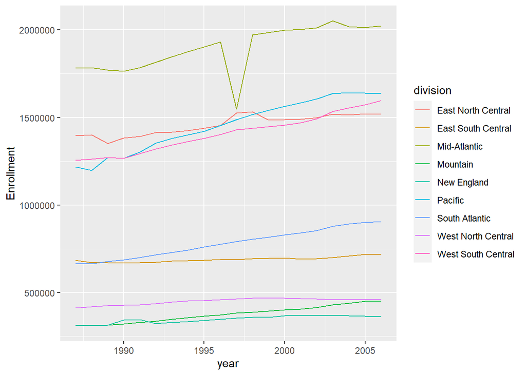

```r
plot(non_County_Comb, var_name = "E_Value")
```

### Plotting county values

- PA, top, 7

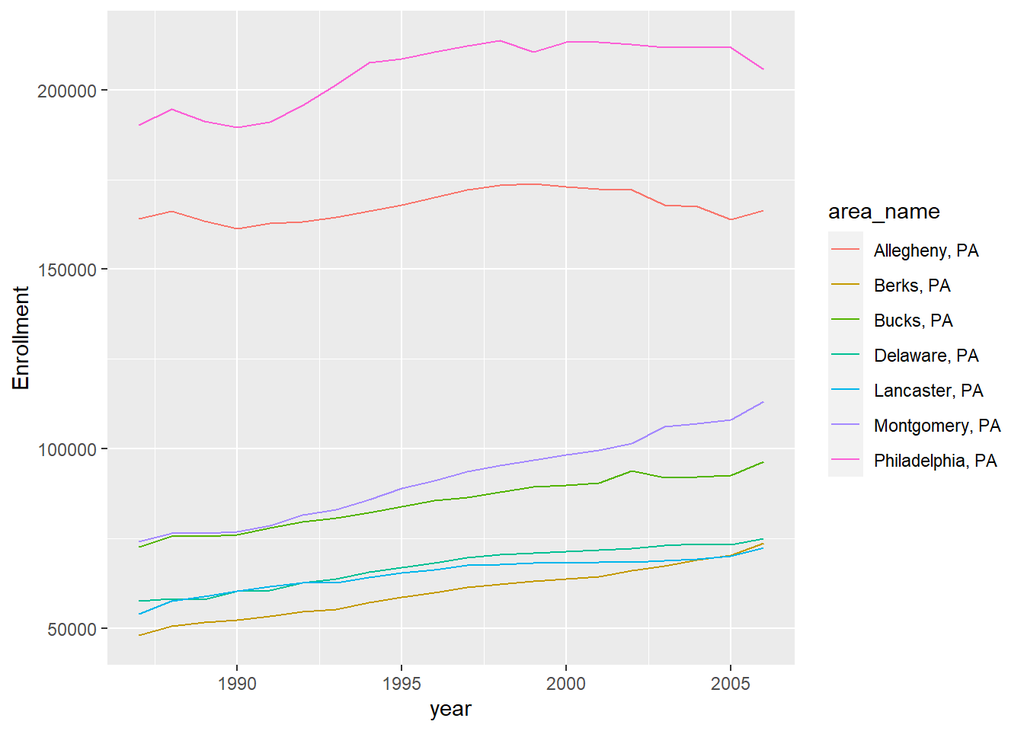

```r
plot(county_Comb, var_name = "E_Value", "PA", "top", 7)
```

- PA, bottom, 4

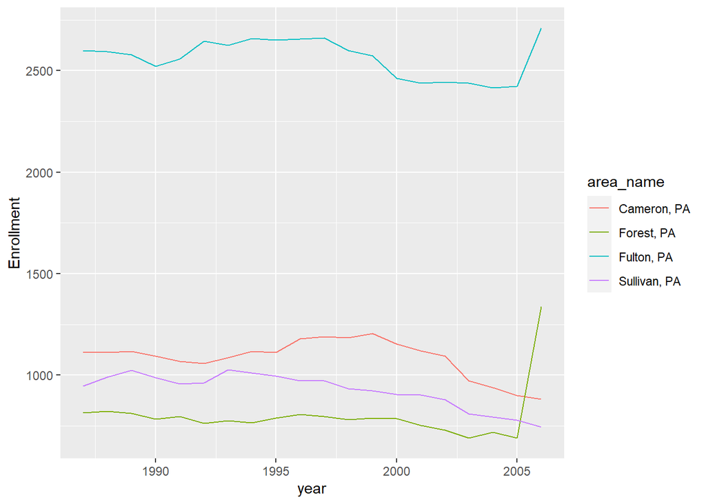

```r
plot(county_Comb, var_name = "E_Value", "PA", "bottom", 4)
```

- Defaults

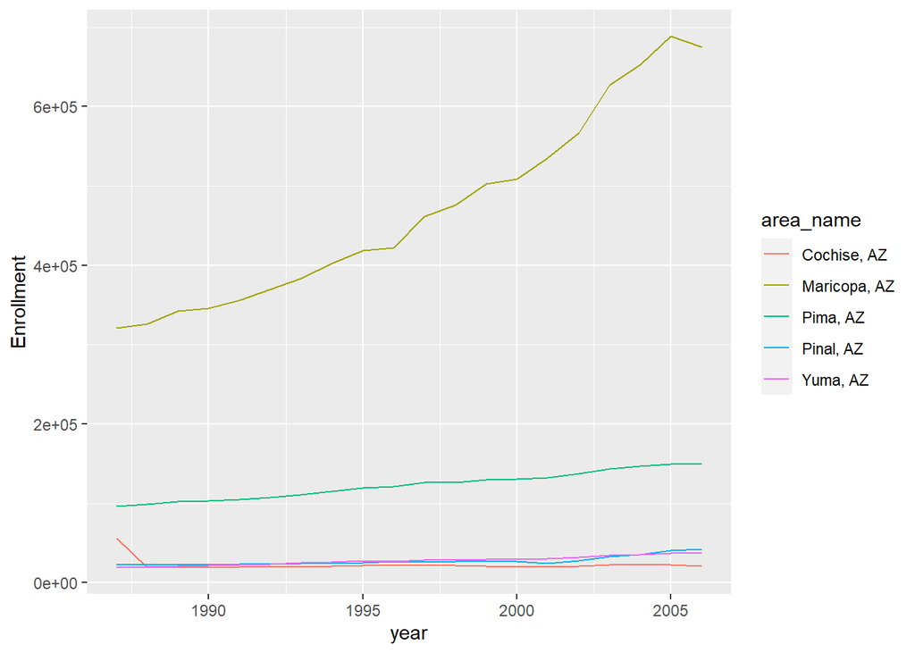

```r
plot(county_Comb, var_name = "E_Value")
```

- MN, top, 10

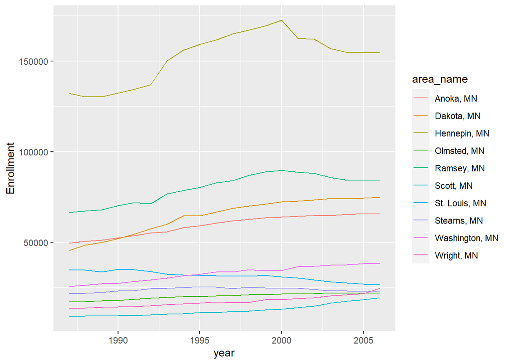

```r
plot(county_Comb, var_name = "E_Value", "MN", "top", 10)
```

# Last steps

Combining 4 data sets by calling combining function 3 times, and separating county and non county data

```r
add_url_1 <- "https://www4.stat.ncsu.edu/~online/datasets/PST01a.csv"
add_url_2 <- "https://www4.stat.ncsu.edu/~online/datasets/PST01b.csv"
add_url_3 <- "https://www4.stat.ncsu.edu/~online/datasets/PST01c.csv"
add_url_4 <- "https://www4.stat.ncsu.edu/~online/datasets/PST01d.csv"

add_df_1 <- my_wrapper(add_url_1, "E_Value")
add_df_2 <- my_wrapper(add_url_2, "E_Value")
add_df_3 <- my_wrapper(add_url_3, "E_Value")
add_df_4 <- my_wrapper(add_url_4, "E_Value")

comb_df_1 <- combine_dfs(add_df_1, add_df_2)
comb_df_2 <- combine_dfs(add_df_3, comb_df_1)
comb_df_3 <- combine_dfs(add_df_4, comb_df_2)
combined_Non_County <- comb_df_3[['Non_County']]
combined_County <- comb_df_3[['County']]
```

All plots below are according to the class type of each object. For “state” type objects (non-county tibbles), the plot for state function is called, while for “county” type objects (county tibbles), the plot function for county is called.

### Plotting state values

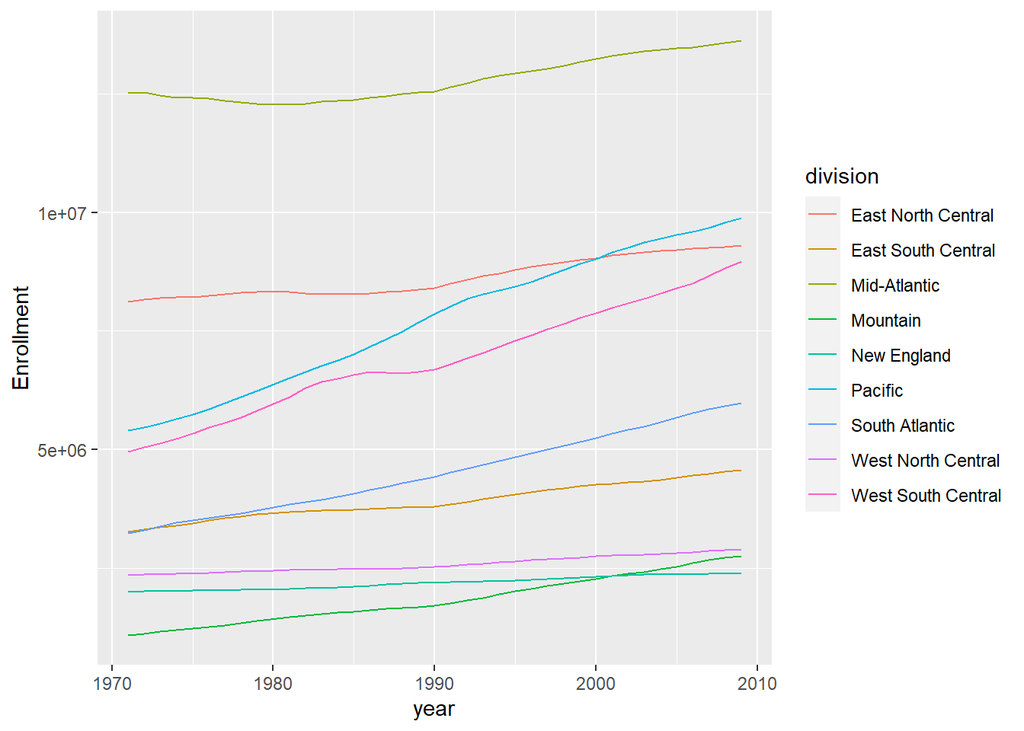

```r
plot(combined_Non_County, var_name = "E_Value")
```

### Plotting county values

- CT, top, 6

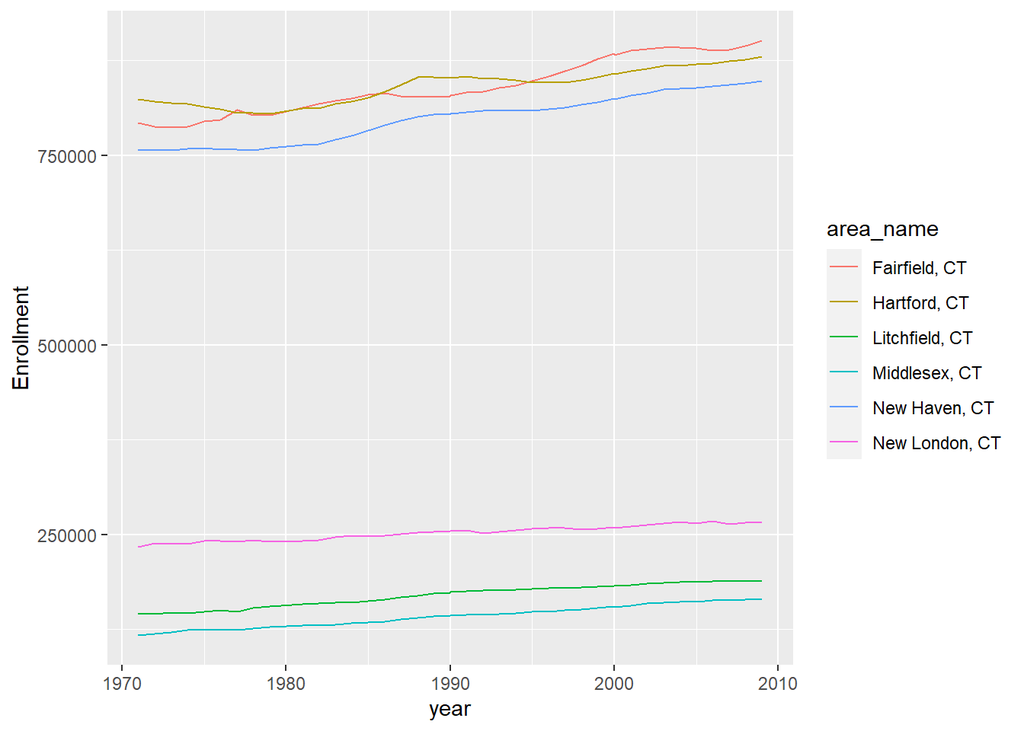

```r
plot(combined_County, var_name = "E_Value", "CT", "top", 6)
```

- NC, bottom, 10

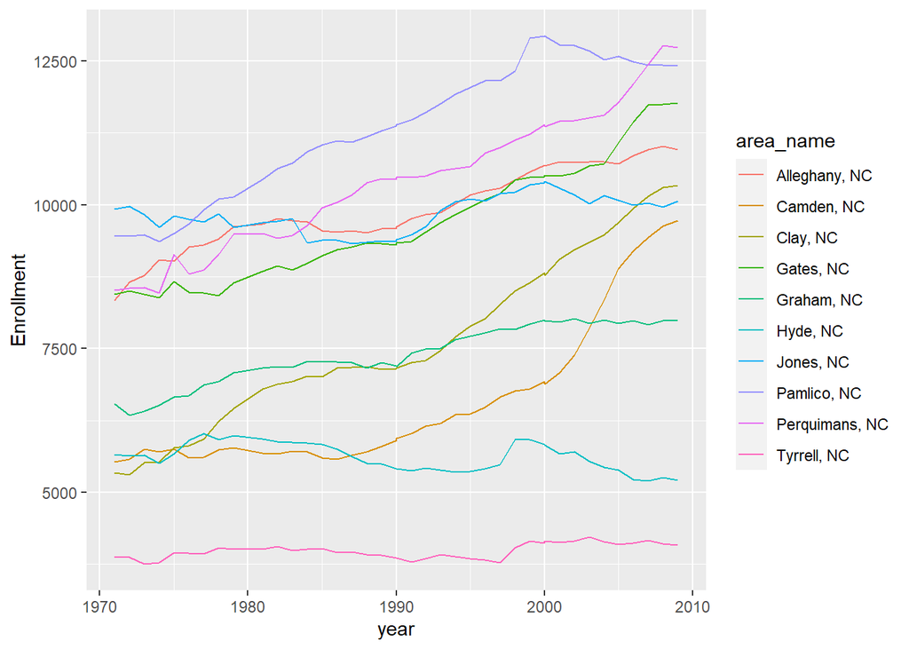

```r
plot(combined_County, var_name = "E_Value", "NC", "bottom", 10)
```

- Defaults

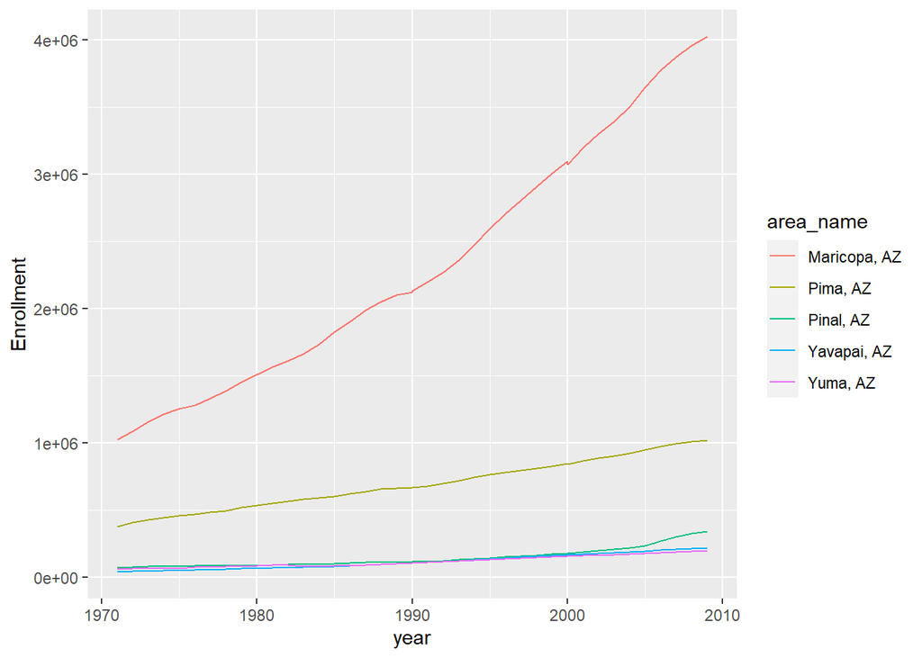

```r
plot(combined_County, var_name = "E_Value")
```

- MN, top, 4

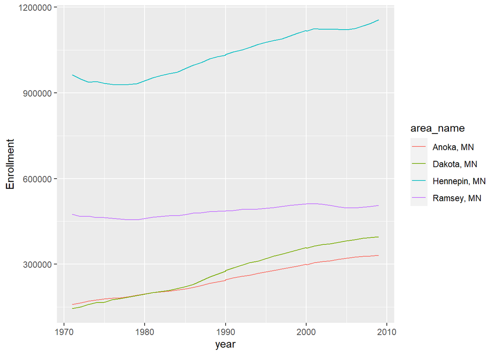

```r
plot(combined_County, var_name = "E_Value", "MN", "top", 4)
```